# 6 Building ARIMA model

## 6.5 Check for stationarity

Stationarity means that wherever you are in your time of your variable you have the same mean and the same variance (dispersion around the mean). It is important beacause if your distribution is changing over time, it gets difficult to forecast.

```python
from statsmodels.tsa.stattools import adfuller
dftest = adfuller(df['Demand'], autolag='AIC')
dftest
```

```
(-2.2350745220924746,
 0.19376252804604438,
 21,
 765,
 {'1%': -3.438926964986094,
  '5%': -2.8653254941943174,
  '10%': -2.5687857802554572},
 7739.43731933071)
```

### Test of stationarity using Dickey-Fuller

```python
#Perform Dickey-Fuller test:
def test_stationarity(timeseries):
    print('Results of Dickey-Fuller Test:')
    dftest = adfuller(timeseries, autolag='AIC')
    dfoutput = pd.Series(dftest[0:4], index=['Test Statistic','p-value','#Lags Used','Number of Observations Used'])
    for key,value in dftest[4].items(): # key, value mapping
        dfoutput['Critical Value (%s)'%key] = value
    print(dfoutput)
    if dftest[0] < dftest[4]["5%"]:
        print ("Reject Ho - Time Series is Stationary")
    else:
        print ("Failed to Reject Ho - Time Series is Non-Stationary")
```

```python
test_stationarity(df["Demand"])
```

```
Results of Dickey-Fuller Test:
Test Statistic                  -2.235075
p-value                          0.193763
#Lags Used                      21.000000
Number of Observations Used    765.000000
Critical Value (1%)             -3.438927
Critical Value (5%)             -2.865325
Critical Value (10%)            -2.568786
dtype: float64
Failed to Reject Ho - Time Series is Non-Stationary
```

### Make one difference

Because our data is non staionary, we are going to take 1 difference out of our data.

```python
#returns to decimals
df = df.astype('float')
# we create the returns
ret = df.Demand - df.Demand.shift(1)
ret.dropna(inplace=True)

ret.head()
```

```
Date
2015-07-02   -115.0
2015-07-03     17.0
2015-07-04     -2.0
2015-07-06    -14.0
2015-07-07      2.0
Name: Demand, dtype: float64
```

Now we add the diffences in a new column

```python
df['Dem_Dif'] = ret
df.dropna(inplace=True)
df.head()
```

| Date | Demand | Dem_Dif |
| --- | --- | --- |
| 2015-07-02 | 1.0 | -115.0 |
| 2015-07-03 | 18.0 | 17.0 |
| 2015-07-04 | 16.0 | -2.0 |
| 2015-07-06 | 2.0 | -14.0 |
| 2015-07-07 | 4.0 | 2.0 |

### Plot our difference column

We plot our difference to check visually if our data is stationary after making one difference.

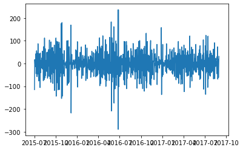

```python
plt.plot(df['Dem_Dif'])
```

From this plot, we visually assume that our data is staionary after making 1 difference. However, in order to be sure, we are going to apply Dickey-Fuller Test again.

```python
test_stationarity(df["Dem_Dif"])
```

```
Results of Dickey-Fuller Test:
Test Statistic                -9.134981e+00
p-value                        2.952328e-15
#Lags Used                     2.100000e+01
Number of Observations Used    7.640000e+02
Critical Value (1%)           -3.438938e+00
Critical Value (5%)           -2.865330e+00
Critical Value (10%)          -2.568788e+00
dtype: float64
Reject Ho - Time Series is Stationary
```

## 6.6 Applying ARIMA model

As we have explained, we are going to use ARIMA model to be able to predict the dependent variable demand based only on itself. We are making a one-day-ahead forecast because the ARIMA is retrained before every forecast.

```python
import warnings
warnings.filterwarnings('ignore')

from statsmodels.tsa.arima_model import ARIMA

X = df["Demand"].values
size = 756

# walk forward validation: train the whole model! at each iteration including the new observation (for the next day)
train, test = X[0:size], X[size:len(X)] # [0:756][756:786]

history = [x for x in train] # "list comprehensions".
expect=[]

predictions = list()
for t in range(len(test)): # 10 times reiterate
    model = ARIMA(history, order=(2,1,0)) # and 10
    model_fit = model.fit(disp=0)
    output = model_fit.forecast()
    yhat = output[0]
    predictions.append(yhat)
    obs = test[t]
    history.append(obs) # appends the real observation at each loop!
    expect.append(obs)
```

### Changing the format of the predicted values

After generating the forecast values, we need to change their format to have 1 dimension to be able to compare the results.

```python
from itertools import chain
def flatten(la):
    "Flatten one level of nesting"
    return chain.from_iterable(la)

l = flatten(predictions)
```

```python
df_Demand = pd.DataFrame(
    {'observations': expect,
     'forecast': l
    })
df_Demand
```

|  | observations | forecast |
| --- | --- | --- |
| 0 | 138.0 | 115.153989 |
| 1 | 157.0 | 125.111823 |
| 2 | 146.0 | 130.671375 |
| 3 | 112.0 | 147.264320 |
| 4 | 92.0 | 140.540994 |
| 5 | 155.0 | 118.875285 |
| 6 | 87.0 | 117.842956 |
| 7 | 133.0 | 112.632479 |
| 8 | 123.0 | 125.399538 |
| 9 | 82.0 | 113.608353 |
| 10 | 173.0 | 115.142639 |
| 11 | 106.0 | 123.403102 |
| 12 | 130.0 | 120.773550 |
| 13 | 129.0 | 137.766738 |
| 14 | 116.0 | 121.222682 |
| 15 | 138.0 | 125.970553 |
| 16 | 127.0 | 127.360617 |
| 17 | 119.0 | 127.114168 |
| 18 | 129.0 | 129.072252 |
| 19 | 117.0 | 125.097065 |
| 20 | 72.0 | 122.212852 |
| 21 | 102.0 | 108.819321 |
| 22 | 117.0 | 97.302880 |
| 23 | 190.0 | 95.508781 |
| 24 | 121.0 | 132.845769 |
| 25 | 141.0 | 143.900855 |
| 26 | 144.0 | 152.321579 |
| 27 | 82.0 | 134.895351 |
| 28 | 61.0 | 125.437849 |
| 29 | 92.0 | 98.765783 |

### Calculating the RMSE of our ARIMA model

```python
from sklearn.metrics import mean_squared_error
def forecast_accuracy(forecast, actual):
    #rmse = np.mean((forecast - actual)**2)**.5  # RMSE
    rmse = np.sqrt(mean_squared_error(forecast, actual))
    return({'rmse':rmse})

def adjust(val, length= 10): return str(val).ljust(length) # 10
print('Forecast Accuracy of: Demand')
accuracy_prod = forecast_accuracy(df_Demand['forecast'].values, df_Demand['observations'].values)
for k, v in accuracy_prod.items():
    print(adjust(k), ': ', round(v,4))
```

```
Forecast Accuracy of: Demand
rmse       :  32.7942
```

### Plot Predicted vs Actual demand

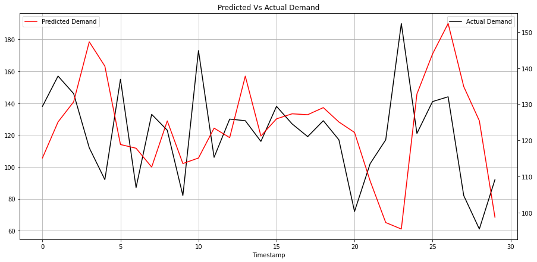

```python
plt.figure(figsize= (15,7))
plt.xlabel("Timestamp")

ax1 = df_Demand.observations.plot(color = 'black', grid = True, label = 'Actual Demand')
ax2 = df_Demand.forecast.plot(color = 'red', grid = True, secondary_y = True, label = 'Predicted Demand')

ax1.legend(loc=1)
ax2.legend(loc=2)
plt.title('Predicted Vs Actual Demand')
plt.show()
```

The plot is showing a hudge difference between the actual and the predicted demand. Maybe we didn't apply the optimal lags. That is why, in the following command, we are going to check different lags to conclude which number is the optimal to work with.

```python
from sklearn.metrics import mean_squared_error
X = df["Demand"].values
# evaluate an ARIMA model for a given order (p,d,q)
def evaluate_arima_model(X, arima_order):
# prepare training dataset
    train_size = int(len(X) * 0.95)
    train, test = X[0:train_size], X[train_size:]
    history = [x for x in train]
    # make predictions
    predictions = list()
    for t in range(len(test)):
        model = ARIMA(history, order=arima_order)
        model_fit = model.fit()
        yhat = model_fit.forecast()[0]
        predictions.append(yhat)
        history.append(test[t])
    # calculate out of sample error
    rmse = np.sqrt(mean_squared_error(test, predictions))
    return rmse
```

```python
# evaluate combinations of p, d and q values for an ARIMA model
def evaluate_models(dataset, p_values, d_values, q_values):
    dataset = dataset.astype('float32')
    best_score, best_cfg = float("inf"), None
    for p in p_values:
        for d in d_values:
            for q in q_values:
                order = (p,d,q)
                try:
                    rmse = evaluate_arima_model(dataset, order)
                    if rmse < best_score:
                        best_score, best_cfg = rmse, order
                    print('ARIMA%s RMSE=%.3f' % (order,rmse))
                except:
                    continue
    print('Best ARIMA%s RMSE=%.3f' % (best_cfg, best_score))
```

```python
p_values = [0, 1, 2, 4]
q_values = [0, 1, 2, 4]
d_values = ([1])
warnings.filterwarnings("ignore")
evaluate_models(X, p_values, d_values, q_values)
```

```
ARIMA(0, 1, 0) RMSE=40.120
ARIMA(0, 1, 1) RMSE=28.961
ARIMA(0, 1, 2) RMSE=28.963
ARIMA(0, 1, 4) RMSE=29.059
ARIMA(1, 1, 0) RMSE=32.415
ARIMA(1, 1, 1) RMSE=28.954
ARIMA(1, 1, 2) RMSE=28.970
ARIMA(1, 1, 4) RMSE=28.408
ARIMA(2, 1, 0) RMSE=31.301
ARIMA(2, 1, 1) RMSE=28.995
ARIMA(2, 1, 2) RMSE=28.575
ARIMA(2, 1, 4) RMSE=27.607
ARIMA(4, 1, 0) RMSE=31.337
ARIMA(4, 1, 1) RMSE=29.001
ARIMA(4, 1, 2) RMSE=28.245
ARIMA(4, 1, 4) RMSE=27.868
Best ARIMA(2, 1, 4) RMSE=27.607
```

The optimal number of lags with the smallest RMSE error seems to be when our p value (number of lags) is 2 and q value (the moving average) is 4.

### Plot our results again using ARIMA (2, 1, 4)

```python
import warnings
warnings.filterwarnings('ignore')

from statsmodels.tsa.arima_model import ARIMA

X = df["Demand"].values
size = 756

# walk forward validation: train the whole model! at each iteration including the new observation (for the next day)
train, test = X[0:size], X[size:len(X)] # [0:756][756:786]

history = [x for x in train] # "list comprehensions".
expect=[]

predictions = list()
for t in range(len(test)): # 10 times reiterate
    model = ARIMA(history, order=(2,1,4)) # and 10
    model_fit = model.fit(disp=0)
    output = model_fit.forecast()
    yhat = output[0]
    predictions.append(yhat)
    obs = test[t]
    history.append(obs) # appends the real observation at each loop!
    expect.append(obs)
```

```python
from itertools import chain
def flatten(la):
    "Flatten one level of nesting"
    return chain.from_iterable(la)

l = flatten(predictions)
```

```python
df_Demand = pd.DataFrame(
    {'observations': expect,
     'forecast': l
    })
df_Demand
```

|  | observations | forecast |
| --- | --- | --- |
| 0 | 138.0 | 133.695968 |
| 1 | 157.0 | 123.920451 |
| 2 | 146.0 | 131.151503 |
| 3 | 112.0 | 134.408149 |
| 4 | 92.0 | 128.664951 |
| 5 | 155.0 | 132.421555 |
| 6 | 87.0 | 123.510961 |
| 7 | 133.0 | 132.535156 |
| 8 | 123.0 | 122.247871 |
| 9 | 82.0 | 127.737206 |
| 10 | 173.0 | 124.582985 |
| 11 | 106.0 | 121.905431 |
| 12 | 130.0 | 129.835685 |
| 13 | 129.0 | 123.296836 |
| 14 | 116.0 | 126.450392 |
| 15 | 138.0 | 127.228287 |
| 16 | 127.0 | 123.589242 |
| 17 | 119.0 | 130.176443 |
| 18 | 129.0 | 123.549190 |
| 19 | 117.0 | 129.114461 |
| 20 | 72.0 | 123.912103 |
| 21 | 102.0 | 123.890182 |
| 22 | 117.0 | 117.246188 |
| 23 | 190.0 | 118.406563 |
| 24 | 121.0 | 124.606033 |
| 25 | 141.0 | 124.543768 |
| 26 | 144.0 | 130.502757 |
| 27 | 82.0 | 123.515732 |
| 28 | 61.0 | 132.717221 |
| 29 | 92.0 | 113.068092 |

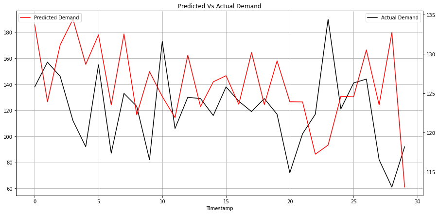

```python
plt.figure(figsize= (15,7))
plt.xlabel("Timestamp")

ax1 = df_Demand.observations.plot(color = 'black', grid = True, label = 'Actual Demand')
ax2 = df_Demand.forecast.plot(color = 'red', grid = True, secondary_y = True, label = 'Predicted Demand')

ax1.legend(loc=1)
ax2.legend(loc=2)
plt.title('Predicted Vs Actual Demand')
plt.show()
```

# 7 Conclusion

To conclude, in the EDA part, we were able to analyze the demand in a detailed way taking into account several variables in our data frame. Theoretically, we believed that there will be some relationship or correlation between our dependent variable and the rest of the variables chosen as predictors. However, the heat map gave us quite different results showing a very low correlation between the variables, which is why we opted for the ARIMA method to forecast the demand by itself.

For this reason, in order to improve the answer to our problematic question, it is recommended to test other models to reach the final conclusion whether the demand is actually forecastable or not.